# House Price Data Example

Aleksandr Tsybakin[^1]

Vadim Tyuryaev[^2]

Jane Heffernan[^3]

Hanna Jankowski[^4]

Kevin McGregor[^5]

## Initial Setup

Import packages.

```r
suppressMessages(library(ggplot2))
suppressMessages(library(visdat))
suppressMessages(library(forcats))
suppressMessages(library(corrplot))
suppressMessages(library(ggpubr))
suppressWarnings(library(gridExtra))
suppressMessages(library(tibble))
suppressMessages(library(dplyr))
suppressMessages(library(naniar))
suppressMessages(library(devtools))
```

Install and import [RegrCoeffsExplorer](https://github.com/vadimtyuryaev/RegrCoeffsExplorer/tree/main) package (Tyuryaev et al. 2024).

```r
devtools::install_github("vadimtyuryaev/RegrCoeffsExplorer",
                         ref="main",
                         build_vignettes=TRUE)
```

```
## Skipping install of 'RegrCoeffsExplorer' from a github remote, the SHA1 (ed53fec0) has not changed since last install.
##   Use `force = TRUE` to force installation
```

```r
suppressMessages(library(RegrCoeffsExplorer))
```

We implemented several helper functions that will be re-used throughout examples under this tutorial.

```r
source("./utils/utils.R")
```

## Introduction

Let us start with loading the dataset for Exploratory Data Analysis (Tukey et al. 1977).

```r
df_hprices = read.csv("./data/house_prices/house_prices.csv")
df_hprices = as_tibble(df_hprices)
df_hprices = df_hprices %>% mutate_if(is.character, as.factor)

# Remove Id column
df_hprices = df_hprices%>%dplyr::select(-c(Id))

dim(df_hprices)
```

```
## [1] 1460   80
```

The initial dataset has information about 1460 properties.

## Exploratory Data Analysis

### Missing Values

First things first - let’s take a look at missing values in the dataset.

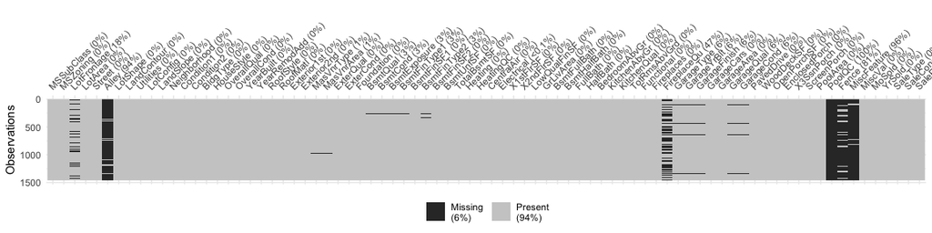

```r
# Plot missing values matrix
vis_miss(df_hprices)
```

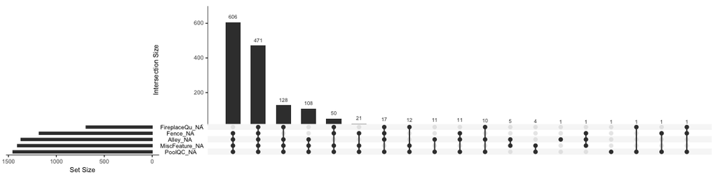

```r
# More detailed missing values analysis
gg_miss_upset(df_hprices)
```

We will remove variables that have more than 5% of missing values (`Alley`, `FireplaceQu`, `PoolQC`, `Fence`, `MiscFeature` and `LotFrontage`).

```r
# Delete columns with >5% missing
df_hprices = subset(df_hprices, select=-c(Alley,
                                          FireplaceQu,
                                          PoolQC,
                                          Fence,
                                          MiscFeature,
                                          LotFrontage))
```

Now let’s take a closer look at the systematic missing values. Systematic missing values appear in data instances with a certain pattern in same fields (Weinberg, Biswas, and Koller 1992). They form a black stripes in missing values matrix below.

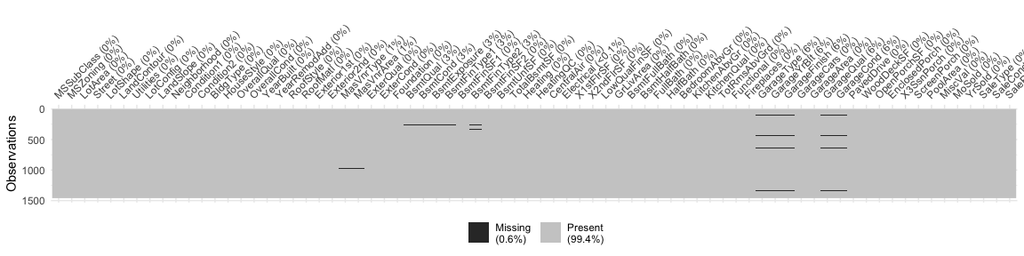

```r
# Plot missing values matrix
vis_miss(df_hprices)
```

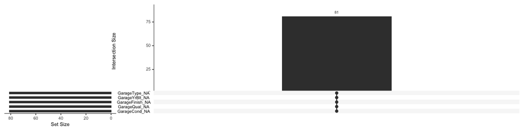

```r
# More detailed missing values analysis
gg_miss_upset(df_hprices)
```

Systematic missing values should be removed as they cannot be imputed based on other columns. We will remove instances with systematic missing values based on the following sets of fields:

1. `BsmtFinType1` and `BsmtExposure`.
2. `MasVnrType` and `MasVnrArea`.
3. `BsmtExposure`, `BsmtFinType2` and `Electrical`.
4. `Garage`-related fields.

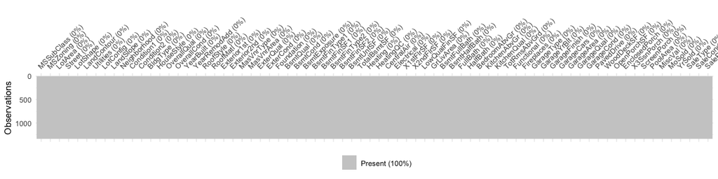

```r
# Remove systematically missing values
df_hprices = df_hprices%>%filter(!(is.na(BsmtFinType1)) & !(is.na(BsmtExposure)))
df_hprices = df_hprices%>%filter(!(is.na(MasVnrType)) & !(is.na(MasVnrArea)))
df_hprices = df_hprices%>%filter(!(is.na(BsmtExposure)) & !(is.na(BsmtFinType2)) & !(is.na(Electrical)))
df_hprices = df_hprices%>%filter(!(is.na(GarageType)))
vis_miss(df_hprices)
```

As we can see from the missing matrix above, we do not have any missing values in the dataset.

### Categorical Variables

Let’s take a look at the categorical variables in the dataset.

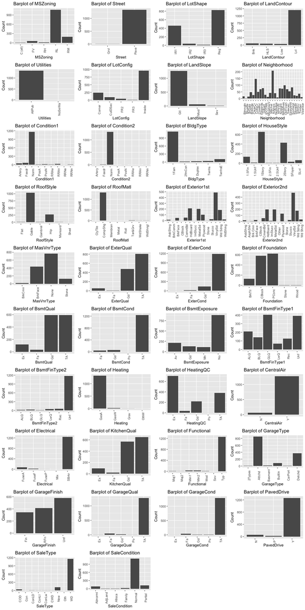

```r
# Select categorical variables
factor_vars = df_hprices %>%
  select_if(is.factor)

# Plot barplots for factor variables
plot_figures(factor_vars, ncol=4, plot_type="bar")
```

Most of the categorical variables are unbalanced. We will perform the following operations:

1. Remove highly unbalanced variables (`Street`, `Utilities`, `Condition2`, `RoofMatl` and `Heating`).
2. Re-balance some of these variables by combining several minor categories into one using the *rebalance_factors()* function defined in the utils file.
3. Manually re-balance the remaining variables (`KitchenQual`, `BsmtFinType1`, `BsmtQual`, `Foundation` and `HouseStyle`).

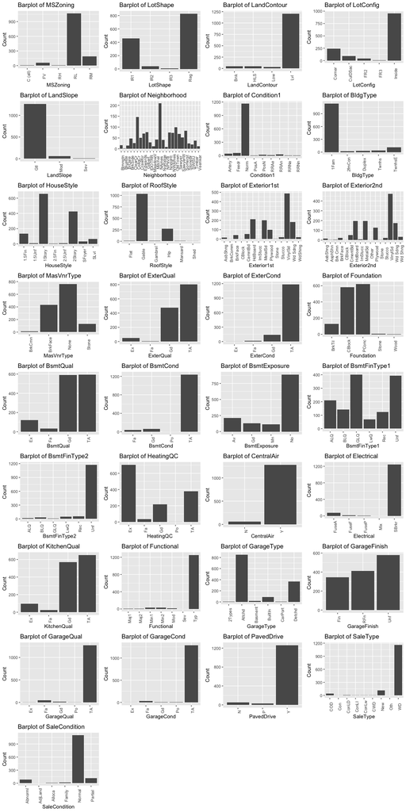

```r
# Remove highly unbalanced factor variables
df_hprices=df_hprices%>%dplyr::select(-c(Street,
                                         Utilities,
                                         Condition2,
                                         RoofMatl,
                                         Heating))

# Select categorical variables
factor_vars = df_hprices %>%
  select_if(is.factor)

# Rebalance factor variables
for (col in colnames(factor_vars)) {
  df_hprices = rebalance_factors(df_hprices, col)
}

# Re-group unbalanced factor variables
df_hprices[["KitchenQual"]] = fct_collapse(df_hprices[["KitchenQual"]],
                                            Other=c("Ex", "Fa"))

df_hprices[["BsmtFinType1"]] = fct_collapse(df_hprices[["BsmtFinType1"]],
                                             Other=c("ALQ", "BLQ", "LwQ", "Rec"))

df_hprices[["BsmtQual"]] = fct_collapse(df_hprices[["BsmtQual"]],
                                         Other=c("Ex", "Fa"))

df_hprices[["Foundation"]] = fct_collapse(df_hprices[["Foundation"]],
                                           Other=c("Stone", "Wood", "BrkTil"))

df_hprices[["HouseStyle"]] = fct_collapse(df_hprices[["HouseStyle"]],
                                           Other=c("1.5Fin", "1.5Unf",
                                                     "2.5Fin", "2.5Unf",
                                                     "SFoyer", "SLvl"))


# Plot barplots for factor variables
plot_figures(factor_vars, ncol=4, plot_type="bar")
```

Also, `Neighborhood`, `Exterior1st` and `Exterior2nd` variables have too many categories which potentially complicates our analysis and plotting. For this reason, we will remove these variables from further analysis and modelling.

```r
# Remove variables with too many categories
df_hprices = df_hprices%>%dplyr::select(-c(Neighborhood,
                                           Exterior1st,
                                           Exterior2nd))

# Check number of columns left
ncol(df_hprices)
```

```
## [1] 66
```

Let’s select the categorical variables that highly statistically significant through Analysis of Variance (ANOVA) (Seiler 2019).

```r
# Select categorical variables
factor_vars = df_hprices %>%
  select_if(is.factor)

# Perform ANOVA for each factor variable with the sales prices variable
anova_results = lapply(factor_vars, function(factor_var) {
  aov_result = aov(SalePrice ~ factor_var, data=df_hprices)
  return(summary(aov_result))
})

# Print the ANOVA results
anova_results
```

```
## $MSZoning
##               Df    Sum Sq   Mean Sq F value Pr(>F)
## factor_var     1 4.952e+11 4.952e+11   84.49 <2e-16 ***
## Residuals   1336 7.831e+12 5.861e+09
## ---
## Signif. codes:  0 '***' 0.001 '**' 0.01 '*' 0.05 '.' 0.1 ' ' 1
##
## $LotShape
##               Df    Sum Sq   Mean Sq F value Pr(>F)
## factor_var     1 5.829e+11 5.829e+11   100.6 <2e-16 ***
## Residuals   1336 7.743e+12 5.796e+09
## ---
## Signif. codes:  0 '***' 0.001 '**' 0.01 '*' 0.05 '.' 0.1 ' ' 1
##
## $LandContour
##               Df    Sum Sq   Mean Sq F value Pr(>F)
## factor_var     1 1.774e+10 1.774e+10   2.852 0.0915 .
## Residuals   1336 8.308e+12 6.219e+09
## ---
## Signif. codes:  0 '***' 0.001 '**' 0.01 '*' 0.05 '.' 0.1 ' ' 1
##
## $LotConfig
##               Df    Sum Sq   Mean Sq F value  Pr(>F)
## factor_var     1 5.195e+10 5.195e+10   8.388 0.00384 **
## Residuals   1336 8.274e+12 6.193e+09
## ---
## Signif. codes:  0 '***' 0.001 '**' 0.01 '*' 0.05 '.' 0.1 ' ' 1
##
## $LandSlope
##               Df    Sum Sq   Mean Sq F value Pr(>F)
## factor_var     1 3.068e+10 3.068e+10   4.942 0.0264 *
## Residuals   1336 8.295e+12 6.209e+09
## ---
## Signif. codes:  0 '***' 0.001 '**' 0.01 '*' 0.05 '.' 0.1 ' ' 1
##
## $Condition1
##               Df    Sum Sq   Mean Sq F value   Pr(>F)
## factor_var     1 9.819e+10 9.819e+10   15.94 6.88e-05 ***
## Residuals   1336 8.228e+12 6.159e+09
## ---
```

[output cut: 152 more lines]

```
## Signif. codes:  0 '***' 0.001 '**' 0.01 '*' 0.05 '.' 0.1 ' ' 1
##
## $SaleType
##               Df    Sum Sq   Mean Sq F value Pr(>F)
## factor_var     1 4.986e+11 4.986e+11   85.09 <2e-16 ***
## Residuals   1336 7.827e+12 5.859e+09
## ---
## Signif. codes:  0 '***' 0.001 '**' 0.01 '*' 0.05 '.' 0.1 ' ' 1
##
## $SaleCondition
##               Df    Sum Sq   Mean Sq F value   Pr(>F)
## factor_var     1 2.458e+11 2.458e+11   40.65 2.51e-10 ***
## Residuals   1336 8.080e+12 6.048e+09
## ---
## Signif. codes:  0 '***' 0.001 '**' 0.01 '*' 0.05 '.' 0.1 ' ' 1
```

```r
# Select only significant at 1% and less, remove others
df_hprices = df_hprices%>%dplyr::select(-c(LandContour,
                                           LotConfig,
                                           LandSlope,
                                           ExterCond,
                                           BsmtCond,
                                           BsmtFinType2))
```

### Continuous Variables

In this section, we will explore continuous variables and prepare them for modelling.

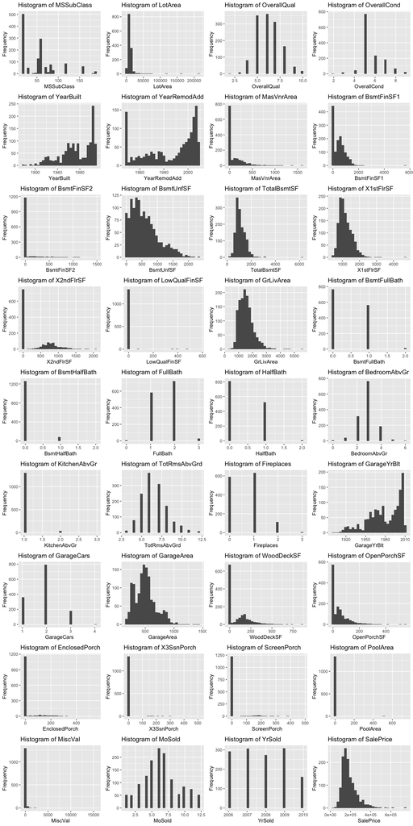

```r
# Select continuous variables
continuous_vars = df_hprices %>%
  select_if(is.numeric)

# Plot histograms for factor numerical variables
plot_figures(continuous_vars, ncol=4, plot_type="hist")
```

The dataset has 3 date variables coded as years (`YrSold`, `YearRemodAdd` and `YearBuilt`). Let us take a look at the `YrSold`. From the histogram above we can see that it’s distribution is close to uniform. Let’s examine the `SalePrice` by year sold via the boxplot.

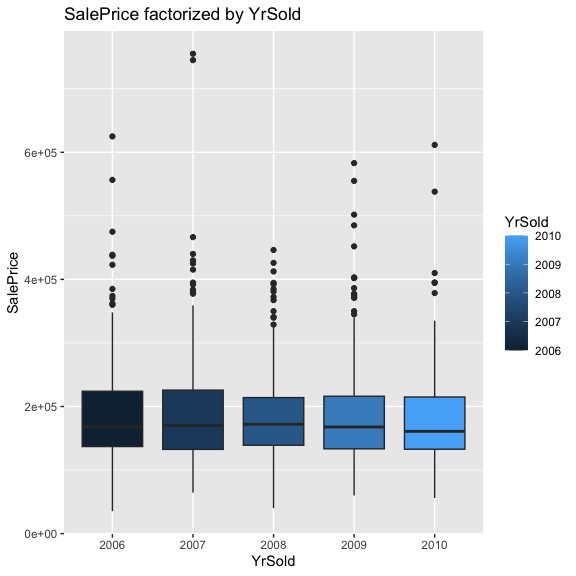

```r
# Plot SalePrice boxplots factorized by YrSold categories
ggplot(df_hprices, aes(x=as.factor(YrSold), y=SalePrice, fill=YrSold)) +
  geom_boxplot() +
  labs(title=paste("SalePrice factorized by YrSold"), x="YrSold")
```

As we can see from boxplots above, the distribution of `SalePrice` values is very similar among different `YrSold` years. For this reason, we will remove this variable from the dataset.

```r
# Remove variables with too many categories
df_hprices = df_hprices%>%dplyr::select(-c(YrSold))
```

The same is not true for the other two variables. Therefore, we will convert year values from these variables into number of years since an event. To do this, we will fix a year when this dataset was released (2018) and call it the *Current Year*. Then, we will subtract the year values from these two variables from the Current Year. As the result, we will get number of years since remodeling (`YearsSinceRemod`) and number of years since the property was built (e.g. age of the property, `YearsSinceBuilt`).

```r
# Set a current year (approximate year when the data was released,
# ref: https://www.kaggle.com/datasets/lespin/house-prices-dataset/data
CUR_YEAR = 2018

# Calculate number of years since remodel
df_hprices$YearsSinceRemod = CUR_YEAR - df_hprices$YearRemodAdd

# Calculate number of years since the property was built
df_hprices$YearsSinceBuilt = CUR_YEAR - df_hprices$YearBuilt

# Remove initial year variables
df_hprices = df_hprices%>%dplyr::select(-c(YearRemodAdd,
                                           YearBuilt))
```

Also, we will remove variables with have highly skewed distribution based on histograms above (`LotArea`, `BsmtFinSF2`, `LowQualFinSF`, `EnclosedPorch`, `X3SsnPorch`, `ScreenPorch`, `PoolArea`, `MiscVal`).

```r
# Remove variables with highly skewed distribution
df_hprices = df_hprices%>%dplyr::select(-c(LotArea,
                                           BsmtFinSF2,
                                           LowQualFinSF,
                                           EnclosedPorch,
                                           X3SsnPorch,
                                           ScreenPorch,
                                           PoolArea,
                                           MiscVal))
```

Let’s look at correlations between remaining continuous variables. We will zero out correlations below $0.65$ for better visual representations.

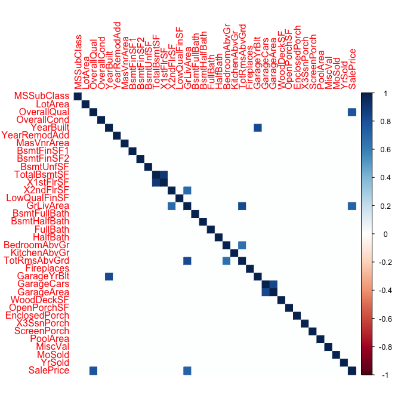

```r
# Calculate the correlation matrix
cor_matrix = cor(continuous_vars)
cor_matrix[abs(cor_matrix) < 0.65] = 0

# Plot the filtered correlation matrix using corrplot
corrplot(cor_matrix, method="color")
```

We will eliminate variables that show high correlation (with absolute values over $0.65$) with other variables. Among those marked for removal, we will retain those with the strongest correlation to the target variable (`SalePrice`).

```r
 # Remove correlated select the one that have higher corr with SP
df_hprices = df_hprices%>%dplyr::select(-c(GarageYrBlt,
                                           TotRmsAbvGrd,
                                           GarageCars,
                                           TotalBsmtSF,
                                           X2ndFlrSF))
```

## Modelling

Now let’s fit a Linear Model to the dataset and analyze the effect of different features of properties on the Sale Price.

```r
# Fit the Linear Model on the dataset
independent_vars = colnames(df_hprices)[!colnames(df_hprices) %in% c("SalePrice")]
formula_str = paste("SalePrice ~", paste(independent_vars, collapse=" + "))
lm_model = lm(as.formula(formula_str), data=df_hprices)
summary(lm_model)
```

```
##
## Call:
## lm(formula = as.formula(formula_str), data = df_hprices)
##
## Residuals:
##     Min      1Q  Median      3Q     Max
## -459965  -13528    -519   12826  227757
##
## Coefficients:
##                       Estimate Std. Error t value Pr(>|t|)
## (Intercept)         -11381.882  19105.185  -0.596 0.551448
## MSSubClass             -67.543     73.052  -0.925 0.355352
## MSZoningRL            3718.691   2869.424   1.296 0.195218
## LotShapeReg          -3770.262   2025.906  -1.861 0.062969 .
## Condition1Norm       15511.912   2751.638   5.637 2.12e-08 ***
## BldgTypeOther        -8584.438   7991.077  -1.074 0.282911
## HouseStyle1Story     11884.937   4520.106   2.629 0.008657 **
## HouseStyle2Story     -8362.336   3851.277  -2.171 0.030090 *
## OverallQual          14224.479   1310.564  10.854  < 2e-16 ***
## OverallCond           5732.580   1145.301   5.005 6.35e-07 ***
## RoofStyleGable       -4505.353   2421.569  -1.861 0.063042 .
## MasVnrTypeNone        9128.680   2681.253   3.405 0.000683 ***
## MasVnrArea              37.648      7.342   5.127 3.39e-07 ***
## ExterQualTA          -8577.379   3145.973  -2.726 0.006489 **
## FoundationCBlock      5921.929   4279.555   1.384 0.166668
## FoundationPConc       9196.503   4762.480   1.931 0.053699 .
## BsmtQualGd          -23350.704   3565.888  -6.548 8.39e-11 ***
## BsmtQualTA          -20595.482   4124.652  -4.993 6.75e-07 ***
## BsmtExposureNo      -11088.918   2221.570  -4.991 6.81e-07 ***
## BsmtFinType1GLQ       5152.022   3024.892   1.703 0.088771 .
## BsmtFinType1Unf      -6724.456   3295.935  -2.040 0.041532 *
## BsmtFinSF1               2.056      4.511   0.456 0.648728
## BsmtUnfSF                2.118      4.753   0.446 0.655951
## HeatingQCOther       -3061.611   2371.905  -1.291 0.197012
## CentralAirY           3066.476   5170.523   0.593 0.553239
## ElectricalSBrkr       -789.095   3930.551  -0.201 0.840919
## X1stFlrSF              -12.065      7.391  -1.632 0.102823
## GrLivArea               64.318      5.664  11.356  < 2e-16 ***
## BsmtFullBath          8987.423   2618.296   3.433 0.000617 ***
## BsmtHalfBath          1664.633   4000.765   0.416 0.677422
```

[output cut: 13 more lines]

```
## GarageCondTA          5073.055   5825.760   0.871 0.384027
## PavedDriveY           2888.702   4350.837   0.664 0.506847
## WoodDeckSF              20.297      7.707   2.634 0.008551 **
## OpenPorchSF             -8.326     15.404  -0.541 0.588909
## MoSold                -111.689    337.890  -0.331 0.741040
## SaleTypeWD           -9669.965   3637.484  -2.658 0.007948 **
## SaleConditionNormal   2536.478   3206.952   0.791 0.429130
## YearsSinceRemod        -86.794     75.484  -1.150 0.250423
## YearsSinceBuilt       -213.582     84.819  -2.518 0.011920 *
## ---
## Signif. codes:  0 '***' 0.001 '**' 0.01 '*' 0.05 '.' 0.1 ' ' 1
##
## Residual standard error: 32640 on 1286 degrees of freedom
## Multiple R-squared:  0.8354, Adjusted R-squared:  0.8289
## F-statistic:   128 on 51 and 1286 DF,  p-value: < 2.2e-16
```

From the p-values above we can see that there are several variables of high significance while analyzing one-unit change effect on the target variable. Let’s take a look at the effect of the difference between Q3 and Q1 (default) in each variable on the target variable. We will use the *vis_reg()* function to visualize both approaches.

More details on *vis_reg()* function can be found in our [vignette](https://vadimtyuryaev.github.io/RegrCoeffsExplorer/articles/BetaVisualizer.html):

```r
# load OddsRatioVisualizer vignette
vignette("BetaVisualizer",
         package="RegrCoeffsExplorer")
```

```
## starting httpd help server ... done
```

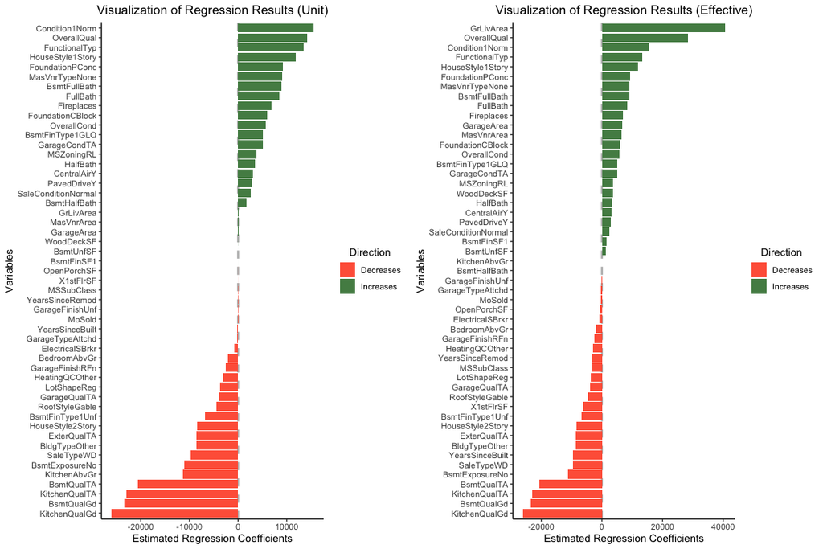

```r
# Plot Odds Ratio for Unit Difference vs. Odds Ratio for difference between Q3 and Q1
grid.arrange(vis_reg(lm_model, palette=c("palegreen4","tomato1"))$"SidebySide")
```

The left barplot shows one-unit difference effect (`Unit plot`), while the right one shows Q3-Q1 difference effect (`Effective`). We can see that variables’ effect is difference on these graphs. In this Kaggle dataset, when considering the empirical distribution, the largest estimated coefficient corresponds to `GrLivArea`, indicating that the feature with the most significant influence on Sale Price is the square footage of above-grade (ground) living area.

```r
# Calculate all possible differences
all_diffs = combn(df_hprices$GrLivArea, 2, function(x) abs(x[1] - x[2]))

# Count differences that are exactly 1 units
num_diffs_exactly_one = sum(abs(all_diffs) == 1)
sprintf("Number of differences of exactly 1 unit: %s", num_diffs_exactly_one)
```

```
## [1] "Number of differences of exactly 1 unit: 960"
```

```r
# Count the proportion of differences that more or equal to 2 units
num_diffs_2_or_more = sum(num_diffs_exactly_one) / sum(abs(all_diffs)) * 100
sprintf("Proportion of differences of one unit: %s%%", num_diffs_2_or_more)
```

```
## [1] "Proportion of differences of one unit: 0.000193132342261709%"
```

Only a fraction of the variations observed in the variable `GrLivArea` amount to a singular unit. Consequently, when interpreting standard regression outputs on a per-unit basis, we are essentially discussing differences that represent only a small fraction of the overall data. Thus, the analysis of standard regression outputs on a per-unit basis implicitly addresses differences that may not be significant in the actual dataset. A more pragmatic approach involves utilizing a tangible observable difference, such as the interquartile range (IQR), to estimate regression coefficients, particularly when considering the empirical distribution of data.

## References

Seiler, C. 2019. “ANOVA.” *Springer Reference Medizin*. https://doi.org/10.1007/978-3-662-48986-4_310185.

Tukey, John Wilder et al. 1977. *Exploratory Data Analysis*. Vol. 2. Springer.

Tyuryaev, Vadim, Aleksandr Tsybakin, Jane Heffernan, Hanna Jankowski, and Kevin McGregor. 2024. *RegrCoeffsExplorer: Efficient Visualization of Regression Coefficients for LM, GLM, and GLMNET Objects*. https://vadimtyuryaev.github.io/RegrCoeffsExplorer/.

Weinberg, J., Gautam Biswas, and G. R. Koller. 1992. “Conceptual Clustering with Systematic Missing Values,” 464–69. https://doi.org/10.1016/b978-1-55860-247-2.50065-6.

[^1]: York University, Mathematics and Statistics, tsybakin@yorku.ca
[^2]: York University, Mathematics and Statistics, vadimtyu@yorku.ca
[^3]: York University, Mathematics and Statistics, jmheffer@yorku.ca
[^4]: York University, Mathematics and Statistics, hkj@yorku.ca
[^5]: York University, Mathematics and Statistics, kevinmcg@yorku.ca